# act_report

## Report: act_report

- Create a **250-word-minimum written report** called "act_report.pdf" or "act_report.html" that communicates the insights and displays the visualization(s) produced from your wrangled data. This is to be framed as an external document, like a blog post or magazine article, for example.

After wrangling and merging all the three datasets, the datasets where combined to create a master dataset. This was first stored as “twitter_archive_master.csv”. Basic analysis was performed on the master dataset. The aim of the analysis was to answer the following questions.

After running the analysis, the following were the findings: With the first question: people that make rating do so via one of these channels;

> - Twitter for iPhone
> - Vine - Make a Scene
> - Twitter Web Client
> - TweetDeck

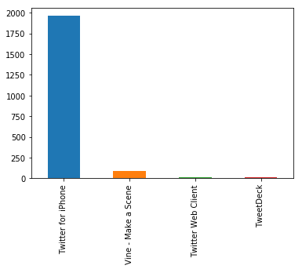

It was clear that a good number of people that do their rating do so by using the Twitter for iPhone app. This constitutes a total number of 1962. This was by Vine – Make a Scene with a total number of 90 before Twitter Web Client with a total number of 12. TweetDeck was found to the channel with least number of people making ratings. Below is a graph for that analysis.

> - golden_retriever 173
> - Labrador_retriever 113
> - Pembroke 96
> - Chihuahua 95
> - pug 65
> - toy_poodle 52
> - chow 51
> - Samoyed 46
> - Pomeranian 42

Below is a graph that shows the picture.

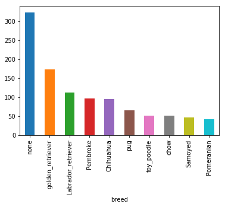

The third question tries to answer which dog stages has the highest and lowest counts. It found out that the “pupper” has the highest with a count of 245. The “doggo, floofer” and “doggo, puppo” had the least with a count of 1 each. Below is a diagram the shows the distribution.

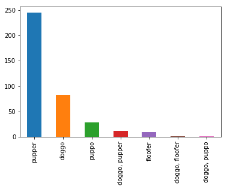